# NP AMR analyses

### Association between plasmids and resistance in *M. catarrhalis*

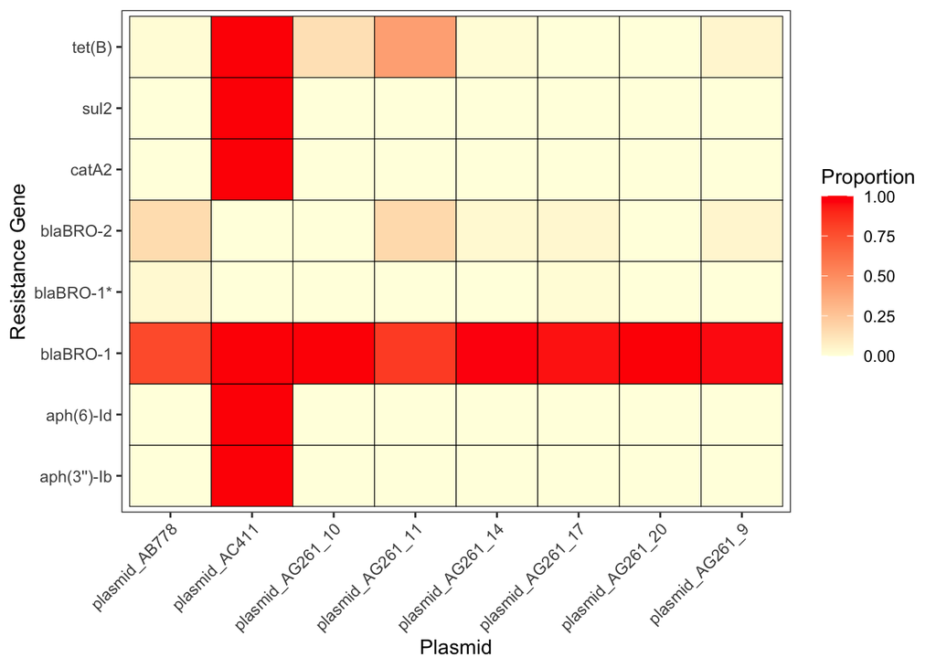

```r
Mcat_plasmid_resistance_prop_df <-
  associate_resistance_plasmids(Mcat_microreact_df,
                                amr_cols = amr_col_names,
                                plasmid_cols = plasmid_cluster_col_names)

ggplot(Mcat_plasmid_resistance_prop_df,
       aes(x = Plasmid,
           y = `Resistance gene`,
           fill = proportion)) +
  geom_tile(color = "black") +
  scale_fill_gradient(low = "lightyellow", high = "red",
                      name = "Proportion") +
  labs(
    x = "Plasmid",
    y = "Resistance Gene"
  ) +
  theme(
    axis.text.x = element_text(angle = 45, hjust = 1),
    panel.grid = element_blank()
  )
```

## Analysis of plasmid gene content

We select the plasmids from the plasmid_reclustering_df to analize in the Bakta tool, then we plot the sequence by gggenes function.

```r
plasmid_representatives_df <-
  plasmid_reclustering_df %>%
   dplyr::group_by(new_plasmid_name) %>%
   dplyr::slice_max(order_by = size, n = 1, with_ties = FALSE) %>%
   dplyr::select(Sample_Name,new_plasmid_name)

plasmid_representatives_df
```

```
## # A tibble: 31 × 2
## # Groups:   new_plasmid_name [31]
##    Sample_Name                                                new_plasmid_name
##    <chr>                                                      <chr>
##  1 36773_2#126_plasmid_AB621                                  plasmid_AB621
##  2 SAMEA4621323_plasmid_AB778                                 plasmid_AB778
##  3 36774_1#279_plasmid_novel_e914484fa6adbecb8a8c8a21bda20586 plasmid_AB946
##  4 46358_2#176_plasmid_AB946                                  plasmid_AB946_27
##  5 46321_2#70_plasmid_AB947                                   plasmid_AB946_30
##  6 46358_2#99_plasmid_AB947                                   plasmid_AB947_24
##  7 46321_1#275_plasmid_AC411                                  plasmid_AC411
##  8 46358_2#52_plasmid_AC497                                   plasmid_AC497_18
##  9 36774_1#56_plasmid_AC497                                   plasmid_AC497_2
## 10 36773_2#239_plasmid_AC497                                  plasmid_AC497_21
## # ℹ 21 more rows
```

```r
set.seed(1)
plasmid_reclustering_df %>%
  dplyr::select(Sample_Name,new_plasmid_name) %>%
  dplyr::group_by(new_plasmid_name) %>%
  dplyr::slice_sample(n = 1)
```

```
## # A tibble: 31 × 2
## # Groups:   new_plasmid_name [31]
##    Sample_Name                                                new_plasmid_name
##    <chr>                                                      <chr>
##  1 36773_2#179_plasmid_AB621                                  plasmid_AB621
##  2 SAMEA4620368_plasmid_AB778                                 plasmid_AB778
##  3 36774_1#279_plasmid_novel_e914484fa6adbecb8a8c8a21bda20586 plasmid_AB946
##  4 36984_2#304_plasmid_AB946                                  plasmid_AB946_27
##  5 46321_2#70_plasmid_AB947                                   plasmid_AB946_30
##  6 46358_2#99_plasmid_AB947                                   plasmid_AB947_24
##  7 46358_2#360_plasmid_AC411                                  plasmid_AC411
##  8 46358_2#52_plasmid_AC497                                   plasmid_AC497_18
##  9 36774_1#56_plasmid_AC497                                   plasmid_AC497_2
## 10 36773_2#239_plasmid_AC497                                  plasmid_AC497_21
## # ℹ 21 more rows
```

### Plasmids in *M. catarrhalis*

#### pAC411

These InterProScan results from 46321_1_275_plasmid_AC411 plasmid indicate that this sequence is primarily a mobile DNA element rather than a metabolic or defense plasmid module. It encodes a site-specific recombinase/resolvase with a catalytic resolvase domain and DNA-binding helix-turn-helix region, together with a large Tn3-like transposase carrying the characteristic DDE transposase domain, which is typical of transposons that mediate DNA rearrangement and movement. Overall, the sequence most likely functions in transposition, recombination, and genomic/plasmid rearrangement, enabling the mobilization or stabilization of associated genetic cargo rather than directly encoding a specialized physiological trait.

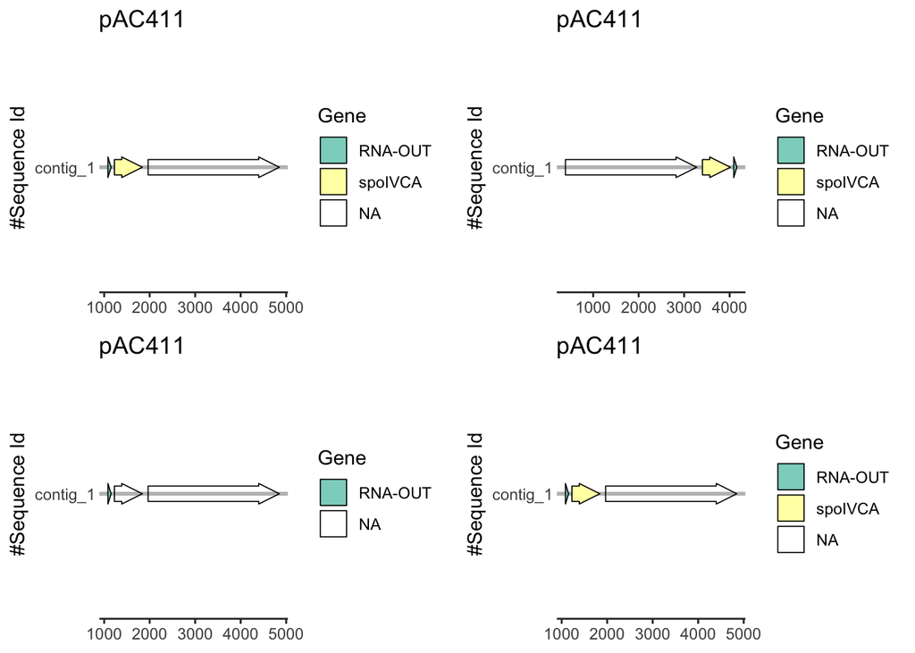

```r
library(cowplot)
cowplot::plot_grid(
  plotlist = list(
    plot_plasmid_function("46321_1_275_plasmid_AC411.tsv", title_str = "pAC411"),
    plot_plasmid_function("46358_2_78_plasmid_AC411.tsv", title_str = "pAC411"),
    plot_plasmid_function("46358_2_175_plasmid_AC411.tsv", title_str = "pAC411"),
    plot_plasmid_function("46358_2_360_plasmid_AC411.tsv", title_str = "pAC411")
  ),
  nrow = 2,
  ncol = 2
)
```

Sunheng interprets the plasmids.

#### pAB778

The new result strengthens the interpretation of this plasmid as mobilizable, because FEFEPI_001 corresponds to a bacterial mobilisation domain-containing protein, supporting a role in DNA processing or transfer during plasmid mobilization. Together with the previously noted mobilization/replication functions and the bacteriocin–immunity/export module, this sequence is best described as a competition-and-defense plasmid that can likely spread between bacteria. Overall, the plasmid most likely promotes interbacterial antagonism, self-protection, and horizontal dissemination of these traits.

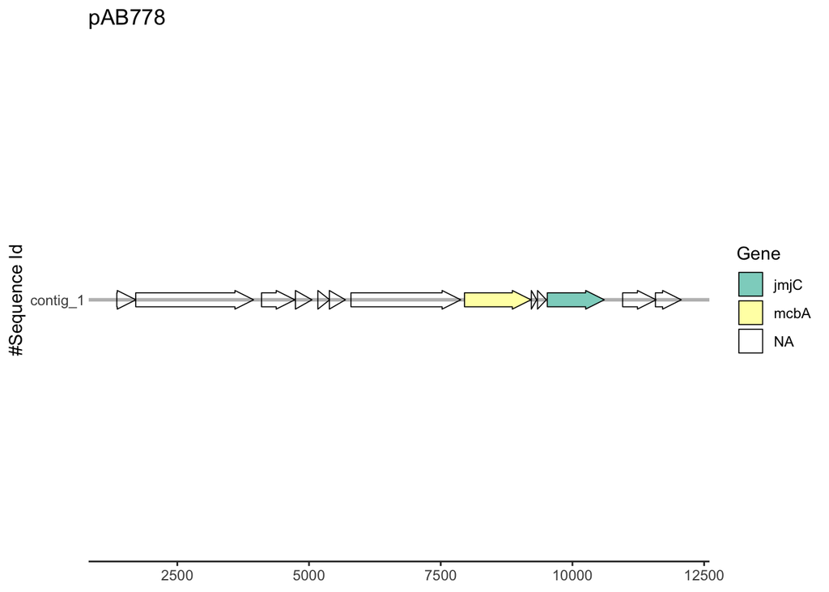

```r
plot_plasmid_function("SAMEA4620300_plasmid_AB778.tsv", title_str = "pAB778")
```